# Part I - FordGoBike Data Analysis and Visualization

*By Irene Nafula*

## Introduction

This data set includes information about individual rides made in a bike-sharing system covering the greater San Francisco Bay area for the month of February 2019.

## Preliminary Wrangling

```python
import pandas as pd
import numpy as np
import matplotlib.pyplot as plt
import seaborn as sns

%matplotlib inline
```

## Data

```python
ford_bike = pd.read_csv('fordgobike-tripdata.csv')
```

```python
ford_bike.sample(20)
```

|  | duration_sec | start_time | end_time | start_station_id | start_station_name | start_station_latitude | start_station_longitude | end_station_id | end_station_name | end_station_latitude | end_station_longitude | bike_id | user_type | member_birth_year | member_gender | bike_share_for_all_trip |
| --- | --- | --- | --- | --- | --- | --- | --- | --- | --- | --- | --- | --- | --- | --- | --- | --- |
| 43995 | 15211 | 2019-02-22 11:39:09.3390 | 2019-02-22 15:52:40.9010 | 27.0 | Beale St at Harrison St | 37.788059 | -122.391865 | 30.0 | San Francisco Caltrain (Townsend St at 4th St) | 37.776598 | -122.395282 | 5306 | Subscriber | 2000.0 | Female | No |
| 132225 | 706 | 2019-02-09 08:54:58.2400 | 2019-02-09 09:06:44.9670 | 278.0 | The Alameda at Bush St | 37.331932 | -121.904888 | 310.0 | San Fernando St at 4th St | 37.335885 | -121.885660 | 2359 | Subscriber | 1995.0 | Male | Yes |
| 42612 | 1906 | 2019-02-22 17:00:02.8770 | 2019-02-22 17:31:49.2180 | 15.0 | San Francisco Ferry Building (Harry Bridges Pl... | 37.795392 | -122.394203 | 31.0 | Raymond Kimbell Playground | 37.783813 | -122.434559 | 6575 | Customer | 1980.0 | Male | No |
| 141895 | 289 | 2019-02-07 17:39:33.2450 | 2019-02-07 17:44:22.4870 | 245.0 | Downtown Berkeley BART | 37.870139 | -122.268422 | 238.0 | MLK Jr Way at University Ave | 37.871719 | -122.273068 | 2869 | Customer | 1977.0 | Other | No |
| 13535 | 642 | 2019-02-27 15:45:19.4000 | 2019-02-27 15:56:02.0340 | 284.0 | Yerba Buena Center for the Arts (Howard St at ... | 37.784872 | -122.400876 | 112.0 | Harrison St at 17th St | 37.763847 | -122.413004 | 5915 | Subscriber | 1965.0 | Male | No |
| 159045 | 328 | 2019-02-05 18:25:00.5080 | 2019-02-05 18:30:28.7550 | 213.0 | 32nd St at Adeline St | 37.823847 | -122.281193 | 156.0 | Stanford Ave at Hollis St | 37.838443 | -122.288665 | 4543 | Subscriber | 1989.0 | Male | No |
| 4564 | 929 | 2019-02-28 15:28:34.3570 | 2019-02-28 15:44:04.3260 | 17.0 | Embarcadero BART Station (Beale St at Market St) | 37.792251 | -122.397086 | 93.0 | 4th St at Mission Bay Blvd S | 37.770407 | -122.391198 | 4970 | Customer | 1988.0 | Male | No |
| 121422 | 747 | 2019-02-11 15:15:14.4130 | 2019-02-11 15:27:41.6450 | 76.0 | McCoppin St at Valencia St | 37.771662 | -122.422423 | 114.0 | Rhode Island St at 17th St | 37.764478 | -122.402570 | 5418 | Subscriber | 1967.0 | Male | No |
| 18068 | 280 | 2019-02-26 19:31:54.4710 | 2019-02-26 19:36:34.8290 | 92.0 | Mission Bay Kids Park | 37.772301 | -122.393028 | 92.0 | Mission Bay Kids Park | 37.772301 | -122.393028 | 2124 | Subscriber | 1968.0 | Male | No |
| 54598 | 1491 | 2019-02-21 12:10:24.7310 | 2019-02-21 12:35:16.4800 | 93.0 | 4th St at Mission Bay Blvd S | 37.770407 | -122.391198 | 16.0 | Steuart St at Market St | 37.794130 | -122.394430 | 6488 | Subscriber | 1985.0 | Male | No |
| 177107 | 950 | 2019-02-02 08:06:04.5600 | 2019-02-02 08:21:54.8470 | 71.0 | Broderick St at Oak St | 37.773063 | -122.439078 | 9.0 | Broadway at Battery St | 37.798572 | -122.400869 | 5368 | Subscriber | 1989.0 | Male | No |
| 121037 | 323 | 2019-02-11 16:16:24.0170 | 2019-02-11 16:21:47.9010 | 66.0 | 3rd St at Townsend St | 37.778742 | -122.392741 | 27.0 | Beale St at Harrison St | 37.788059 | -122.391865 | 5125 | Subscriber | 1980.0 | Male | No |
| 133642 | 1055 | 2019-02-08 18:27:55.9180 | 2019-02-08 18:45:31.1830 | 363.0 | Salesforce Transit Center (Natoma St at 2nd St) | 37.787492 | -122.398285 | 123.0 | Folsom St at 19th St | 37.760594 | -122.414817 | 5329 | Subscriber | 1991.0 | Female | No |
| 39585 | 614 | 2019-02-23 08:13:22.4730 | 2019-02-23 08:23:37.3270 | 129.0 | Harrison St at 20th St | 37.758862 | -122.412544 | 89.0 | Division St at Potrero Ave | 37.769218 | -122.407646 | 5440 | Subscriber | 1964.0 | Other | No |
| 150086 | 841 | 2019-02-06 18:23:59.0320 | 2019-02-06 18:38:00.9200 | 148.0 | Horton St at 40th St | 37.829705 | -122.287610 | 162.0 | Franklin St at 9th St | 37.800516 | -122.272080 | 4623 | Subscriber | 1985.0 | Male | No |
| 75407 | 1024 | 2019-02-19 08:58:07.0580 | 2019-02-19 09:15:11.5280 | 119.0 | 18th St at Noe St | 37.761047 | -122.432642 | 80.0 | Townsend St at 5th St | 37.775235 | -122.397437 | 5898 | Subscriber | NaN | NaN | No |
| 177211 | 468 | 2019-02-02 01:34:27.7240 | 2019-02-02 01:42:15.7750 | 109.0 | 17th St at Valencia St | 37.763316 | -122.421904 | 141.0 | Valencia St at Cesar Chavez St | 37.747998 | -122.420219 | 5274 | Subscriber | 1980.0 | Male | No |
| 37793 | 729 | 2019-02-23 13:17:41.7200 | 2019-02-23 13:29:51.3470 | 17.0 | Embarcadero BART Station (Beale St at Market St) | 37.792251 | -122.397086 | 16.0 | Steuart St at Market St | 37.794130 | -122.394430 | 4657 | Subscriber | 1988.0 | Male | No |
| 8076 | 875 | 2019-02-28 08:30:33.7350 | 2019-02-28 08:45:08.9010 | 125.0 | 20th St at Bryant St | 37.759200 | -122.409851 | 363.0 | Salesforce Transit Center (Natoma St at 2nd St) | 37.787492 | -122.398285 | 5504 | Subscriber | 1985.0 | Male | No |
| 37085 | 227 | 2019-02-23 14:52:58.9220 | 2019-02-23 14:56:46.8090 | 136.0 | 23rd St at San Bruno Ave | 37.754436 | -122.404364 | 139.0 | Garfield Square (25th St at Harrison St) | 37.751017 | -122.411901 | 5856 | Subscriber | 1987.0 | Male | No |

## What is the structure of your dataset?

```python
ford_bike.shape
```

```
(183412, 16)
```

```python
ford_bike.info()
```

```
<class 'pandas.core.frame.DataFrame'>
RangeIndex: 183412 entries, 0 to 183411
Data columns (total 16 columns):
 #   Column                   Non-Null Count   Dtype
---  ------                   --------------   -----
 0   duration_sec             183412 non-null  int64
 1   start_time               183412 non-null  object
 2   end_time                 183412 non-null  object
 3   start_station_id         183215 non-null  float64
 4   start_station_name       183215 non-null  object
 5   start_station_latitude   183412 non-null  float64
 6   start_station_longitude  183412 non-null  float64
 7   end_station_id           183215 non-null  float64
 8   end_station_name         183215 non-null  object
 9   end_station_latitude     183412 non-null  float64
 10  end_station_longitude    183412 non-null  float64
 11  bike_id                  183412 non-null  int64
 12  user_type                183412 non-null  object
 13  member_birth_year        175147 non-null  float64
 14  member_gender            175147 non-null  object
 15  bike_share_for_all_trip  183412 non-null  object
dtypes: float64(7), int64(2), object(7)
memory usage: 22.4+ MB
```

```python
ford_bike.isnull().sum()
```

```
duration_sec                  0
start_time                    0
end_time                      0
start_station_id            197
start_station_name          197
start_station_latitude        0
start_station_longitude       0
end_station_id              197
end_station_name            197
end_station_latitude          0
end_station_longitude         0
bike_id                       0
user_type                     0
member_birth_year          8265
member_gender              8265
bike_share_for_all_trip       0
dtype: int64
```

## Main features of interest in the dataset

I'm most interested in the age of the riders, their gender,the length of the rides and whether or not they are subscribers. I assume that riders who have subscribed will have longer rides because the fact that they are subscribed indicates their level of interest to some extent.

## Cleaning the data

**Define**

Make a copy of the dataframe

**Code**

```python
#make a copy of the dataframe
ford_copy = ford_bike.copy()
```

**Define**

Check for duplicate records

**Code**

```python
#checking for number of duplicate records
ford_duplicates = ford_copy.duplicated().sum()
print('There are {} duplicate records'.format(ford_duplicates))
```

```
There are 0 duplicate records
```

**Define**

Check that the columns have the right dataypes

**Code**

```python
ford_copy.info()
```

```
<class 'pandas.core.frame.DataFrame'>
RangeIndex: 183412 entries, 0 to 183411
Data columns (total 16 columns):
 #   Column                   Non-Null Count   Dtype
---  ------                   --------------   -----
 0   duration_sec             183412 non-null  int64
 1   start_time               183412 non-null  object
 2   end_time                 183412 non-null  object
 3   start_station_id         183215 non-null  float64
 4   start_station_name       183215 non-null  object
 5   start_station_latitude   183412 non-null  float64
 6   start_station_longitude  183412 non-null  float64
 7   end_station_id           183215 non-null  float64
 8   end_station_name         183215 non-null  object
 9   end_station_latitude     183412 non-null  float64
 10  end_station_longitude    183412 non-null  float64
 11  bike_id                  183412 non-null  int64
 12  user_type                183412 non-null  object
 13  member_birth_year        175147 non-null  float64
 14  member_gender            175147 non-null  object
 15  bike_share_for_all_trip  183412 non-null  object
dtypes: float64(7), int64(2), object(7)
memory usage: 22.4+ MB
```

**Define**

Convert `bike_id` to string as it will not be used in any calculations.

**Code**

```python
# convert bike_id to string as it is will not be used in any calculations
ford_copy['bike_id'] = ford_copy['bike_id'].astype(str)
```

**Test**

```python
ford_copy['bike_id'].dtype
```

```
dtype('O')
```

**Define**

Remove records without gender or year of birth as this will be vital in analysis.

**Code**

```python
# Remove records without gender or year of birth
ford_copy.dropna(subset = ['member_birth_year', 'member_gender'], inplace=True)
```

**Test**

member_birth_year and member_gender should have 0 null values

```python
# member_birth_year and member_gender should have 0 null values
ford_copy.isnull().sum()
```

```
duration_sec                 0
start_time                   0
end_time                     0
start_station_id           195
start_station_name         195
start_station_latitude       0
start_station_longitude      0
end_station_id             195
end_station_name           195
end_station_latitude         0
end_station_longitude        0
bike_id                      0
user_type                    0
member_birth_year            0
member_gender                0
bike_share_for_all_trip      0
dtype: int64
```

**Define**

We create a colum for age which will be derived from `member_birth_year` so that we can use it to remove any unreasonable ages or outliers from the data. We will also convert it into an integer type since `member_birth_year` is in float.

**Code**

```python
# create age column
ford_copy['age'] = 2022-ford_copy['member_birth_year'].astype(int)
```

```python
# check maximum age
oldest = ford_copy['age'].max()
print('The oldest rider is {} years old'.format(oldest))
```

```
The oldest rider is 144 years old
```

```python
youngest = ford_copy['age'].min()
print('The youngest rider is {} years old'.format(youngest))
```

```
The youngest rider is 21 years old
```

144 years is not exactly reasonable so we will remove records with ages greater than 100 years

```python
too_old = ford_copy[ford_copy['age'] > 100]
too_old[['user_type', 'member_gender', 'age']]
```

|  | user_type | member_gender | age |
| --- | --- | --- | --- |
| 1285 | Subscriber | Male | 122 |
| 10827 | Subscriber | Male | 122 |
| 16087 | Subscriber | Male | 122 |
| 17981 | Subscriber | Male | 102 |
| 18885 | Subscriber | Male | 102 |
| ... | ... | ... | ... |
| 171996 | Subscriber | Male | 122 |
| 173711 | Subscriber | Male | 122 |
| 177708 | Subscriber | Male | 122 |
| 177885 | Subscriber | Female | 120 |
| 182830 | Subscriber | Male | 121 |

75 rows × 3 columns

```python
# drop the rows
ford_copy = ford_copy.drop(too_old.index, axis=0)
```

**Test**

```python
ford_copy.shape
```

```
(175072, 17)
```

**Define**

Change datatypes of some of the columns to datetime and add a minutes and hours column from `duration_sec` column. That way it will be easier to consume the data at a glance. We will also create a column that stores the duration in hours.

- Convert `start_time` and `end_time` to datetime
- Create a column `duration_minutes'
- Create a column `duration_hours` by dividing `duration_minutes` by 60
- Change `user_type` and `member_gender` to categories

**Code**

```python
# change to datetime
ford_copy['start_time'] = pd.to_datetime(ford_copy['start_time'])
ford_copy['end_time'] = pd.to_datetime(ford_copy['end_time'])
ford_copy = ford_copy.sort_values(by='start_time')
```

```python
# create column duration_minutes
ford_copy['duration_minutes'] = ford_copy['duration_sec']/60
```

```python
# create column duration_hour
ford_copy['duration_hours'] = ford_copy['duration_minutes']/60
```

```python
# change user_type to category
ford_copy.user_type = ford_copy.user_type.astype('category')
# change member_gender to category
ford_copy.member_gender = ford_copy.member_gender.astype('category')
```

**Test**

```python
ford_copy[['start_time', 'end_time', 'duration_sec', 'duration_minutes', 'duration_hours']].sample(5)
```

|  | start_time | end_time | duration_sec | duration_minutes | duration_hours |
| --- | --- | --- | --- | --- | --- |
| 123469 | 2019-02-11 09:10:50.103 | 2019-02-11 09:29:26.372 | 1116 | 18.600000 | 0.310000 |
| 34255 | 2019-02-24 07:27:59.662 | 2019-02-24 07:29:43.676 | 104 | 1.733333 | 0.028889 |
| 32180 | 2019-02-24 15:02:14.198 | 2019-02-24 15:06:58.509 | 284 | 4.733333 | 0.078889 |
| 146952 | 2019-02-07 08:20:37.429 | 2019-02-07 08:28:07.508 | 450 | 7.500000 | 0.125000 |
| 172898 | 2019-02-03 14:10:39.481 | 2019-02-03 14:29:05.412 | 1105 | 18.416667 | 0.306944 |

**Define**

We notice that for the `start_time` and `end_time` columns, the time is together with the dates. So we will extract the date(month and day) from `start_time`. The year is 2019.

**Code**

```python
# extract month
ford_copy['start_time_month'] = ford_copy['start_time'].dt.strftime('%B')
```

```python
# extract day
ford_copy['start_time_day'] = ford_copy['start_time'].dt.strftime('%a')
```

```python
# change both to category datatype
ford_copy.start_time_month = ford_copy.start_time_month.astype('category')
ford_copy.start_time_day = ford_copy.start_time_day.astype('category')
```

**Test**

```python
ford_copy.info()
```

```
<class 'pandas.core.frame.DataFrame'>
Int64Index: 175072 entries, 183411 to 15
Data columns (total 21 columns):
 #   Column                   Non-Null Count   Dtype
---  ------                   --------------   -----
 0   duration_sec             175072 non-null  int64
 1   start_time               175072 non-null  datetime64[ns]
 2   end_time                 175072 non-null  datetime64[ns]
 3   start_station_id         174877 non-null  float64
 4   start_station_name       174877 non-null  object
 5   start_station_latitude   175072 non-null  float64
 6   start_station_longitude  175072 non-null  float64
 7   end_station_id           174877 non-null  float64
 8   end_station_name         174877 non-null  object
 9   end_station_latitude     175072 non-null  float64
 10  end_station_longitude    175072 non-null  float64
 11  bike_id                  175072 non-null  object
 12  user_type                175072 non-null  category
 13  member_birth_year        175072 non-null  float64
 14  member_gender            175072 non-null  category
 15  bike_share_for_all_trip  175072 non-null  object
 16  age                      175072 non-null  int32
 17  duration_minutes         175072 non-null  float64
 18  duration_hours           175072 non-null  float64
 19  start_time_month         175072 non-null  category
 20  start_time_day           175072 non-null  category
dtypes: category(4), datetime64[ns](2), float64(9), int32(1), int64(1), object(4)
memory usage: 24.0+ MB
```

```python
ford_copy[['start_time', 'start_time_month', 'start_time_day']].sample(5)
```

|  | start_time | start_time_month | start_time_day |
| --- | --- | --- | --- |
| 19964 | 2019-02-26 14:41:46.889 | February | Tue |
| 64124 | 2019-02-20 12:54:30.580 | February | Wed |
| 76179 | 2019-02-19 08:36:17.909 | February | Tue |
| 103638 | 2019-02-14 11:52:18.318 | February | Thu |
| 147987 | 2019-02-07 06:33:52.467 | February | Thu |

**Define**

We'd like to know the distance covered by the riders in kilometers so we create a column `distance_km` based on the longitude and latitude start and end points

**Code**

```python
import math
def distance(origin, destination):
    lat1, long1 = origin
    lat2, long2 = destination
    radius = 6371 #km
    dlat = math.radians(lat2-lat1)
    dlong = math.radians(long2-long1)
    a = math.sin(dlat/2) * math.sin(dlat/2) + math.cos(math.radians(lat1)) \
* math.cos(math.radians(lat2)) * math.sin(dlong/2) * math.sin(dlong/2)
    c = 2 * math.atan2(math.sqrt(a), math.sqrt(1-a))
    d = radius * c
    return d
```

```python
ford_copy['distance_km'] = ford_copy.apply(lambda i: distance([i['start_station_longitude'],i['start_station_latitude']],
                            [i['end_station_longitude'],i['end_station_latitude']]), axis=1)
```

```python
ford_copy[['bike_id', 'age', 'distance_km']].sample(5)
```

|  | bike_id | age | distance_km |
| --- | --- | --- | --- |
| 179009 | 5554 | 34 | 1.458113 |
| 171539 | 2876 | 29 | 0.231637 |
| 13445 | 4061 | 28 | 0.676270 |
| 11104 | 1358 | 57 | 0.914859 |
| 179112 | 4631 | 35 | 1.957223 |

## Univariate Exploration

**What is the distribution of users?**

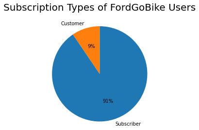

```python
user_counts = ford_copy['user_type'].value_counts()
plt.pie(user_counts, labels = user_counts.index, autopct='%1.0f%%', startangle=90, counterclock = False)
plt.title("Subscription Types of FordGoBike Users", fontsize=20, y=1.07)
plt.axis('square');
```

There are more subscribers than customers which means that the service is very popular in the San Francisco area

**What is the age distribution of FordGoBike users?**

We will use a boxplot to find out what age of users dominates the service as well as the average age of the users.

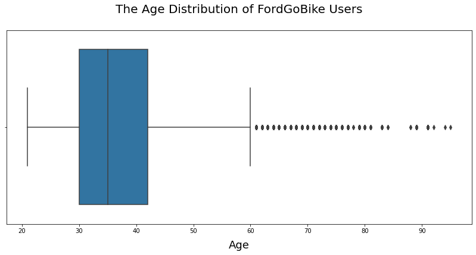

```python
plt.figure(figsize=(14,6))
sns.boxplot(x='age', data=ford_copy)
plt.title("The Age Distribution of FordGoBike Users", fontsize=20, y=1.07)
plt.xlabel("Age", fontsize=18, labelpad=10);
```

```python
avg_age = ford_copy.age.mean()
print('The average age of FordGoBike users is {} years old'.format(avg_age))
```

```
The average age of FordGoBike users is 37.157666560043864 years old
```

```python
ford_copy['age'].describe()
```

```
count    175072.000000
mean         37.157667
std           9.968551
min          21.000000
25%          30.000000
50%          35.000000
75%          42.000000
max          95.000000
Name: age, dtype: float64
```

After cleaning the data, it is observed that most users are between 30 and 40 years old and there are very few users who above 60 years old. The youngest user is 21 years old while the oldest user is 95 years old.

**What is the gender distribution of the users?**

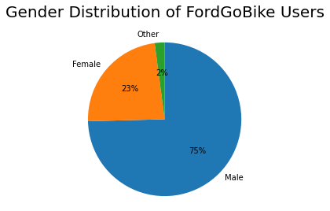

```python
user_counts = ford_copy['member_gender'].value_counts()
plt.pie(user_counts, labels = user_counts.index, autopct='%1.0f%%', startangle=90, counterclock = False)
plt.title("Gender Distribution of FordGoBike Users", fontsize=20, y=1.07)
plt.axis('square');
```

There are more male riders than female riders. Male riders constitute of 75% of all FordGoBike users while female riders constitute of only 23%

**Which day has the most rides?**

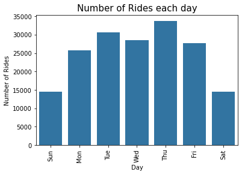

```python
base_color = sns.color_palette()[0]

category_order = ['Sun', 'Mon', 'Tue', 'Wed', 'Thu', 'Fri', 'Sat']
sns.countplot(data=ford_copy, x='start_time_day', order=category_order, color=base_color)
plt.title('Number of Rides each day', fontsize=15)
plt.xlabel('Day')
plt.ylabel('Number of Rides')
plt.xticks(rotation = 90);
```

The day with the most rides is Thursday followed closely by Tuesday, Wednesday and Friday. The days with the lowest rides are Sunday and Saturday.

**Which hour of the day does most users prefer to start their rides?**

We start by extracting the hour from `start_time` to help us find what hour of the day most users prefer to start their rides.

```python
# Extract hour from the start_time
ford_copy['start_hour'] = ford_copy['start_time'].dt.hour
```

```python
ford_copy[['start_time', 'start_hour']].sample(5)
```

|  | start_time | start_hour |
| --- | --- | --- |
| 152007 | 2019-02-06 16:30:22.758 | 16 |
| 179214 | 2019-02-01 14:54:38.973 | 14 |
| 182397 | 2019-02-01 08:05:26.321 | 8 |
| 377 | 2019-02-28 21:42:11.144 | 21 |
| 106376 | 2019-02-13 18:07:05.158 | 18 |

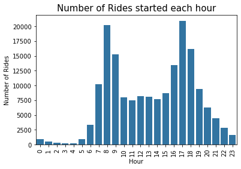

```python
base_color = sns.color_palette()[0]

hour_order = [0, 1, 2, 3, 4, 5, 6, 7, 8, 9, 10, 11, 12, 13, 14, 15, 16, 17, 18, 19, 20, 21, 22, 23]
sns.countplot(data=ford_copy, x='start_hour', order=hour_order, color=base_color)
plt.title('Number of Rides started each hour', fontsize=15)
plt.xlabel('Hour')
plt.ylabel('Number of Rides')
plt.xticks(rotation = 90);
```

From the chart above, most users prefer to start their rides at 0800h and 1700h followed by 1800h and 0900h.

**What is the distance travelled?**

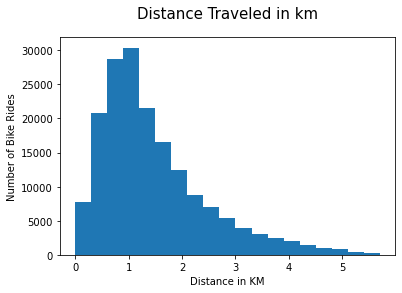

```python
bin_edges = np.arange(0, 6, 0.3)
plt.hist(data = ford_copy, x = 'distance_km', bins = bin_edges)
plt.title("Distance Traveled in km", y = 1.06, fontsize = 15)
plt.xlabel('Distance in KM')
plt.ylabel('Number of Bike Rides');
```

```python
avg_dist = ford_copy['distance_km'].mean()
print('The average distance is {} kilometers'.format(avg_dist))
```

```
The average distance is 1.4784869600080301 kilometers
```

```python
ford_copy['distance_km'].describe()
```

```
count    175072.000000
mean          1.478487
std           1.038283
min           0.000000
25%           0.770858
50%           1.197651
75%           1.938951
max          63.800190
Name: distance_km, dtype: float64
```

The longest distance covered is 63 kilometers and the avarage distance covered by the riders is around 1.4 kilometers.

**How long do the rides last?**

```python
ford_copy['duration_minutes'].describe()
```

```
count    175072.000000
mean         11.737253
std          27.365527
min           1.016667
25%           5.383333
50%           8.500000
75%          13.150000
max        1409.133333
Name: duration_minutes, dtype: float64
```

Most rides last an average of 11 minutes and most people don't go beyond 13 minutes.The longest ride is 1409 minutes which is about 23 hours

## Bivariate Exploration

**What is the daily usage of each of the user types?**

For this, we look at how subscribers use the service and how non subscribers use the service as well.

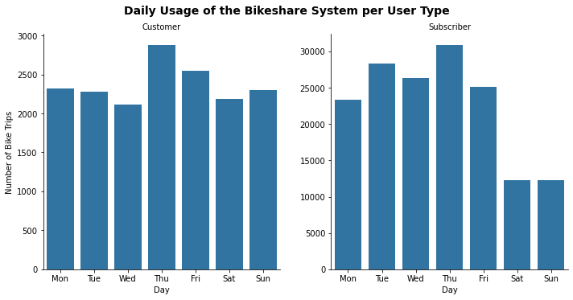

```python
cat_order = ['Mon', 'Tue', 'Wed', 'Thu', 'Fri', 'Sat', 'Sun']
k = sns.catplot(data=ford_copy, x='start_time_day', col="user_type", kind='count', sharey = False, order = cat_order, color = base_color)
k.set_axis_labels("Day", "Number of Bike Trips")
k.set_titles("{col_name}")
k.fig.suptitle('Daily Usage of the Bikeshare System per User Type', y=1.03, fontsize=14, fontweight='semibold');
```

**Which hour of the day does each user type prefer to start their rides?**

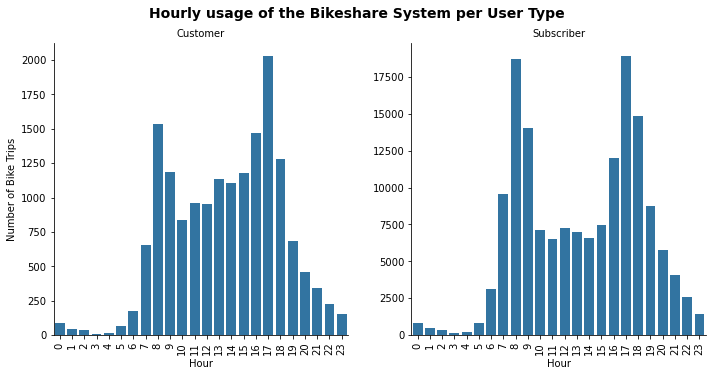

```python
hour_order = [0, 1, 2, 3, 4, 5, 6, 7, 8, 9, 10, 11, 12, 13, 14, 15, 16, 17, 18, 19, 20, 21, 22, 23]
m = sns.catplot(data=ford_copy, x='start_hour', col="user_type", kind='count', order=hour_order, sharex = True, sharey = False,
            color = base_color)
m.set_axis_labels("Hour", "Number of Bike Trips")
m.set_titles("{col_name}")
m.fig.suptitle('Hourly usage of the Bikeshare System per User Type', y=1.03, fontsize=14, fontweight='semibold')
m.set_xticklabels(rotation=90);
```

The analysis above indicates that customers use the service mostly on Thursday, Friday, Sunday, Monday and Tuesday. Subscribers however use the service mostly on weekdays and occasionally on the weekends, that is, Saturday and Sunday.

**What is the distance covered by each user type?**

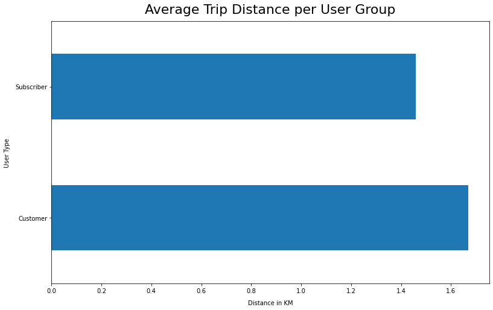

```python
ke = ford_copy.groupby('user_type')['distance_km'].mean().plot(kind='barh', figsize=(13,8))
ke.set_title('Average Trip Distance per User Group', fontsize=22, y=1.015)
ke.set_ylabel('User Type', labelpad=8)
ke.set_xlabel('Distance in KM', labelpad=10);
```

```python
ford_copy.groupby(by='user_type')['distance_km'].mean()
```

```
user_type
Customer      1.669680
Subscriber    1.458425
Name: distance_km, dtype: float64
```

The bar chart demonstrates that on average, customers take longer rides than subscribers. The mean for customers is 1.67 km, and the mean for subscribers is 1.46 km.

**What is the relationship between age of the users and the distance covered?**

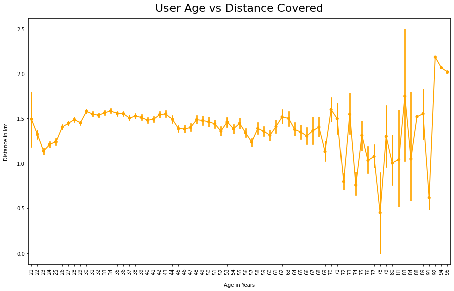

```python
plt.figure(figsize=(15,9))
sns.pointplot(data=ford_copy, x='age', y='distance_km', scale=.7, color='orange')
plt.title('User Age vs Distance Covered', fontsize=22, y=1.015)
plt.xlabel('Age in Years', labelpad=16)
plt.ylabel('Distance in km', labelpad=16)
plt.xticks(rotation = 90);
```

The line graph shows that the longest and shortest rides fluctuate between the older users who are above 70 years of age.

```python
ford_copy['distance_km'].min()
```

```
0.0
```

## Multivariate Exploration

**What is the relationship between gender of each user type and their hourly usage?**

[figure not shown]

```python
hour_order = [0, 1, 2, 3, 4, 5, 6, 7, 8, 9, 10, 11, 12, 13, 14, 15, 16, 17, 18, 19, 20, 21, 22, 23]
k = sns.catplot(data=ford_copy, x='start_hour', col="user_type", hue='member_gender', kind='count', sharey = False,
                order = hour_order)
k.set_axis_labels("Hour of the day", "Number of Bike Trips")
k._legend.set_title('Gender')
k.set_titles("{col_name}")
k.fig.suptitle('FordGoBike usage per User Type and Gender, based on the day of the week', y=1.03, fontsize=14, fontweight='semibold');
```

From the chart above:

**Customers**

- Most female customers start their rides at 1700h followed by 0800h and 1300h and 1600h
- Most male customers start their rides at 1700h followed by 1600h and 0800h.
- Most customers who identify as other start their rides at 1700h and 0800h

**What is the relationship between gender of each user type and their daily usage?**

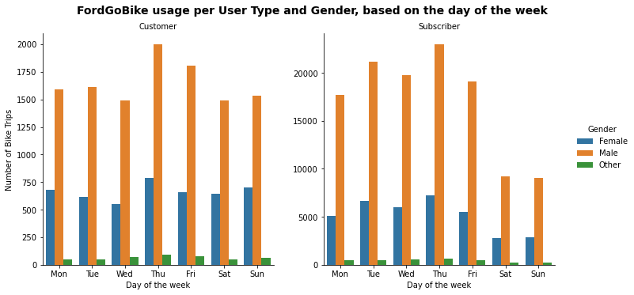

```python
the_day = ['Mon', 'Tue', 'Wed', 'Thu', 'Fri', 'Sat', 'Sun']
k = sns.catplot(data=ford_copy, x='start_time_day', col="user_type", hue='member_gender', kind='count', sharey = False,
                order = the_day)
k.set_axis_labels("Day of the week", "Number of Bike Trips")
k._legend.set_title('Gender')
k.set_titles("{col_name}")
k.fig.suptitle('FordGoBike usage per User Type and Gender, based on the day of the week', y=1.03, fontsize=14, fontweight='semibold');
```

From the charts above, we can see that male customers prefer to ride on Thursdays and Fridays while female customers prefer to ride on Thursday and Sunday. Customers who identify as `other` prefer to ride on Thursdays and Fridays while subscribers of the same category prefer to ride on Wednesdays and Thursdays.

A heat map of the same would look something like this.

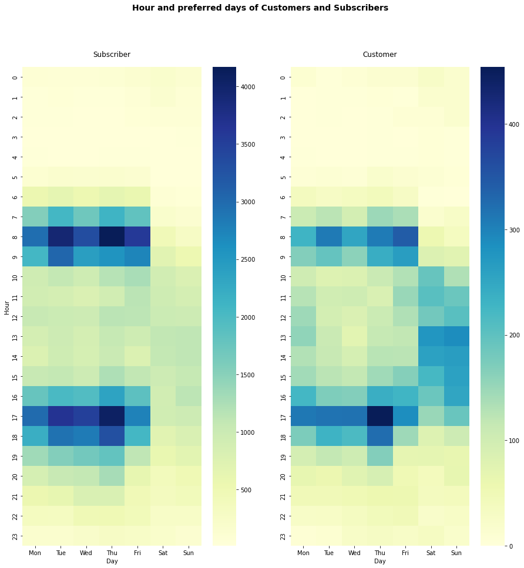

```python
ford_copy['start_time_day'] = pd.Categorical(ford_copy['start_time_day'],
                                             categories=['Mon', 'Tue', 'Wed', 'Thu', 'Fri', 'Sat', 'Sun'], ordered=True)
plt.figure(figsize=(15,15))
plt.suptitle('Hour and preferred days of Customers and Subscribers', fontsize=14, fontweight='semibold')

# heatmap for subscribers
plt.subplot(1, 2, 1)
ford_subscriber = ford_copy.query('user_type == "Subscriber"').groupby(
    ['start_hour', 'start_time_day'])['bike_id'].size().reset_index()
ford_subscriber = ford_subscriber.pivot('start_hour', 'start_time_day', 'bike_id')
sns.heatmap(ford_subscriber, cmap='YlGnBu')

plt.title("Subscriber", y=1.015)
plt.xlabel('Day')
plt.ylabel('Hour');

# heatmap for customers
plt.subplot(1, 2, 2)
ford_customer = ford_copy.query('user_type == "Customer"').groupby([ 'start_hour', 'start_time_day'])['bike_id'].size().reset_index()
ford_customer = ford_customer.pivot('start_hour', 'start_time_day', 'bike_id')
sns.heatmap(ford_customer, cmap="YlGnBu")


plt.title("Customer", y=1.015)
plt.xlabel('Day')
plt.ylabel('');
```

**What is the distance travelled by gender and age of the users?**

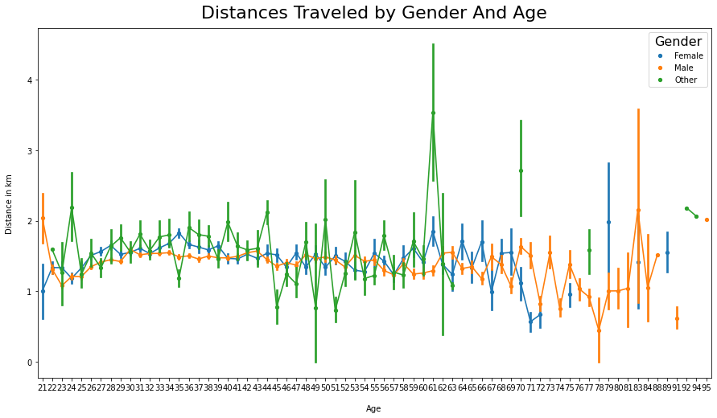

```python
plt.figure(figsize=(15,8))
ke = sns.pointplot(x='age', y='distance_km', hue='member_gender', scale=.6, data=ford_copy)
plt.title('Distances Traveled by Gender And Age', fontsize=22, y=1.015)
plt.xlabel('Age', labelpad=16)
plt.ylabel('Distance in km', labelpad=16)
leg = ke.legend()
leg.set_title('Gender',prop={'size':16})
ke = plt.gca();
```

The gender of users who identify as other have a lot more fluctuations than the others followed by male.

## Conclusions

Records with ages above 100 years old were removed as well as records without gender.

- Subscribers prefer to use the FordGoBike System on the weekdays and not very much on the weekend while customers prefer to use the service mostly on Thursday an Friday.
- The most popular hour of the day preferred by both users is in the evening at 1700h.
- Subscribers prefer to start their rides at 0800h and 1700h while customers prefer to start their rides at 1700h

**References**

- [Extract hour from datetime field](https://stackoverflow.com/questions/25129144/pandas-return-hour-from-datetime-column-directly)